# AI_Tupro1

Kaenova Mahendra Auditama<sup>1</sup>  
Adhe Akram Azhari<sup>2</sup>  
Elita Aurora Az Zahra<sup>3</sup>  
<sup>1</sup>kaenova@student.telkomuniversity.ac.id  
<sup>2</sup>adheakramazhari@student.telkomuniversity.ac.id  
<sup>3</sup>elitaaurora@student.telkomuniversity.ac.id  
Informatics Engineering, Telkom University, Indonesia  
2021

Proyek ini merupakan proyek pertama dari Mata Kuliah Pengantar Kecerdasan Buatan dari 3 proyek yang akan di buat. Proyek pertama ini mengimplementasikan teknik searching dalam Kecerdasan Buatan dengan Genetic Algorithm. Pada algoritma ini kami membuat populasi dan generasi yang dapat diatur. Hal lain juga kami mengimplementasikan Elitisme. Pada penyeleksian orang tua, kami menggunakan fitness kompetisi dimana akan diambil sebanyak (Jumlah Populasi - Jumlah Elitism) sehingga generasi yang terbaru akan dibuat dari Elitisme serta hasil Crossover.

Pada algoritma ini dibutuhkan library `tqdm`. Untuk menginstallnya gunakan command berikut:

```
pip install tqdm
```

atau

```
conda install tqdm
```

## Overview Tugas

Pada tugas yang diberikan, kami diminta untuk membuat suatu program yang menerapkan suatu teknik searching dengan menggunakan suatu konsep kecerdasan buatan. Dalam hal ini kami diminta untuk membuat dengan menggunakan Genetic Algorithm.

Tugas tersebut memberikan kita suatu masalah untuk mencari nilai **maksimum** dari suatu fungsi:

[figure not shown]

dengan batasan x = [-1, 2] dan y = [-1, 1]

## Rancangan Algoritma

Untuk menyelesaikan tugas tersebut kami merancang algoritma sesuai pada diagram di bawah:

[figure not shown]

[figure not shown]

Untuk merubah genotip-genotip tersebut menjadi suatu nilai x dan y kami menggunakan suatu rumus seperti di bawah ini:

[figure not shown]

## Import Libraries

Library python yang harus di masukkan untuk menjalankan algoritma ini

```python
import random
    import math
    import matplotlib.pyplot as plt
    from time import sleep
    from tqdm import tqdm
```

## Chromosome Class

Untuk membuat kromosom, kami merancang bahwa kromosom akan dibuat sebagai suatu objek yang memiliki beberapa prosedur seperti pengdekodean genotip menjadi suatu nilai x dan y serta untuk menghitung fitness dari kromosom itu sendiri.

```python
class kromosome():
        panjang = 8

        def decodeX(self):
            Rmin = -1
            Rmax = 2
            self.x = 0
            self.x = Rmin + (Rmax - Rmin)*((self.kromosom[0]*10**-1)+(self.kromosom[1]*10**-2)+(self.kromosom[2]*10**-3)+(self.kromosom[3]*10**-4))/((9*10**-1)+(9*10**-2)+(9*10**-3)+(9*10**-4))

        def decodeY(self):
            Rmin = -1
            Rmax = 1
            self.y = 0
            self.y = Rmin + (Rmax - Rmin)*((self.kromosom[4]*10**-1)+(self.kromosom[5]*10**-2)+(self.kromosom[6]*10**-3)+(self.kromosom[7]*10**-4))/((9*10**-1)+(9*10**-2)+(9*10**-3)+(9*10**-4))

        def CalculateFitness(self):
            self.fitness = (math.cos(self.x**2)* math.sin(self.y**2))+(self.x+self.y)

        def PrintKromosome(self):
            print("Fitness: {}".format(self.fitness))
            print("Fenotip X: {} Y: {}".format(self.x, self.y))
            print("Genotipe: {} \n".format(self.kromosom))

        def __init__(self):
            self.kromosom = []
            self.fitness = 0
            self.x = 0
            self.y = 0
            for i in range(8):
                self.kromosom.append(random.randint(0, 9))
            self.decodeX()
            self.decodeY()
```

## Genetic Algorithm Procedure and Function

Fungsi dan Prosedur utama yang dibutuhkan untuk menjalankan algoritma ini

### Initialize Population

Dalam prosedur ini digunakan sebagai generasi pertama, dimana akan digunakan untuk membuat kromosom sebanyak jumlah yang ditentukan.

```python
def initialize_population(population_made):
        population = []
        for i in range(population_made): #variable
            kromosome_temp = kromosome()
            population.append(kromosome_temp)
        return population
```

### CalculateKromosomeFitness

Fungsi ini digunakan untuk menghitung fitness pada setiap kromosom.

```python
def calculateKromosomeFitness(population):
        for i in range(len(population)):
            population[i].CalculateFitness()
```

### PopulationFitnessSort

Dalam algoritma ini kami akan melakukan elitism dan selection parent sehingga dibutuhkan fungsi yang mengembalikan kromosom secara terurut mengecil dari berdasarkan fitness tersebut.

```python
def PopulationFitnessSort(population: [kromosome()]):
        population = sorted(population, key=lambda x: x.fitness, reverse= 1)

        return population
```

### GetElitism

Fungsi ini akan mengambil kromosom terbaik dari suatu populasi yang sudah diurutkan dari yang terbesar menuju ke terkecil. Banyaknya yang diambil sebesar 1/5 dari total populasi yang ada.

```python
def getElitism(population):
        get_selection = (math.floor(len(population)/ 5))
        if get_selection % 2 != 0:
            get_selection += 1
        elitism = []
        for i in range(get_selection):
            elitism.append(population[i])

        return elitism
```

### TournamentSelection

Fungsi ini akan mengambil kromosom-kromosom dari populasi berdasarkan fitness. Yang terambil sebanyak 4/5 dari populasi dan index yang mulai diambil merupakan index dari 1/10 populasi.

```python
def tournamentSelection(population):
        get_selection = (math.floor(len(population)/ 5))
        if get_selection % 2 != 0:
           get_selection += 1
        jum_parent = (len(population) - get_selection)
        start_parent = int((get_selection / 2) - 1)
        parent = []
        for i in range(jum_parent) :
            parent.append(population[start_parent + i])

        return parent
```

Gambaran untuk Tournament Selection dan Mengambil Elitism Tersebut seperti di bawah ini:

[figure not shown]

### MatingPool

Dari Fungsi TournamentSelection, pada mating pool ini akan memasangkan parent-parent tersebut untuk dipersiapkan melakukan crossover.

```python
def MatingPool(parent = [kromosome()]):
        parent_temp = parent
        pasangan = []
        j = 0

        for i in range(int(len(parent)/2)):
            pasangan_temp = []
            random_angka_parent = random.randint(1, (len(parent_temp)-1))
            # Copyrighted by Kaenova Mahendra Auditama, Adhe Akram Azhari, Elita Aurora Az Zahra
            pasangan_temp.append(parent_temp[0])
            pasangan_temp.append(parent_temp[random_angka_parent])
            pasangan.append(pasangan_temp)
            parent_temp.pop(random_angka_parent)
            parent_temp.pop(0)
            j = j + 1

        return pasangan
```

### Crossover

Crossover ini mempunyai kemungkinan sebesar 0.85 untuk terjadi hal tersebut. Setelah melakukan pemasang-masangan pada fungsi MatingPool dilakukan crossover pada titik yang random di genotip. Sehingga pada suatu pasangan akan menghasilkan 2 anak (child).

[figure not shown]

```python
def crossover(pasangan = [[kromosome],[kromosome]]):
        populasi_anak = []
        for i in range(len(pasangan)):
            temp_pasangan = pasangan[i]
            random_num = random.uniform(0, 1)
            if random_num < 0.85:
                parent1 = temp_pasangan[0]
                parent2 = temp_pasangan[1]
                panjang_potong = random.randint(1,parent1.panjang - 2)
                kromosome_temp_1 = kromosome()
                kromosome_temp_2 = kromosome()
                kromosome_temp_1.kromosom = parent1.kromosom[:panjang_potong] + parent2.kromosom[panjang_potong:]
                # Copyrighted by Kaenova Mahendra Auditama, Adhe Akram Azhari, Elita Aurora Az Zahra
                kromosome_temp_2.kromosom = parent2.kromosom[:panjang_potong] + parent1.kromosom[panjang_potong:]
                populasi_anak.append(kromosome_temp_1)
                populasi_anak.append(kromosome_temp_2)
            else:
                populasi_anak.append(temp_pasangan[0])
                populasi_anak.append(temp_pasangan[1])

        return populasi_anak
```

### Mutation

```python
def mutation(children):
        for i in range(len(children)):
            for j in range(children[i].panjang):
                random_mutation = random.uniform(0,1)
                if (random_mutation < 0.1 ): #Setup mutasi
                    if (children[i].kromosom[j] + 1 == 10):
                        children[i].kromosom[j] -= 1
                    elif ((children[i].kromosom[j] - 1 == -1)):
                        children[i].kromosom[j] += 1
                    else:
                        random_mutation = random.uniform(0,1)
                        if (random_mutation > 0.5):
                            children[i].kromosom[j] += 1
                        else:
                            children[i].kromosom[j] -= 1

        return children
```

## Other Procedure or Function

Kami juga membutuhkan prosedur atau fungsi lain yang bukan menjadi hal utama dalam algoritma ini, tetapi untuk membantu tracking generasi dan kromosom yang terjadi ketika algoritma ini berjalan

```python
def printAllKromosome(population = [kromosome()]):
        for i in range(len(population)):
            population[i].PrintKromosome()

    def printBestKromosom(best: kromosome, generasi):
        print(" Best Fitness from Generation {}".format(generasi+1))
        # Coded by Kaenova Mahendra Auditama (kaenova@gmail.com)
        # *not responsible if someone plagirized or copied my code
        print("Fitness: {}".format(best.fitness))
        print("Fenotip X: {} Y: {}".format(best.x, best.y))
        print("Genotipe: {} \n".format(best.kromosom))
```

## MAIN

```
How many population do you want to have?
     [Input Even Number over 10] : 100
    How many generation do you want to have?: 1000
```

```
 Best Fitness from Generation 1
    Fitness: 2.451372766969522
    Fenotip X: 0.9672967296729678 Y: 0.9907990799079907
    Genotipe: [6, 5, 6, 7, 9, 9, 5, 3]

     Best Fitness from Generation 77
    Fitness: 2.465504749946626
    Fenotip X: 0.9204920492049209 Y: 0.9929992999299928
    Genotipe: [8, 1, 4, 8, 8, 6, 4, 4]

     Best Fitness from Generation 197
    Fitness: 2.4670687633302135
    Fenotip X: 0.7980798079807978 Y: 0.995999599959996
    Genotipe: [7, 3, 7, 8, 2, 5, 1, 7]

     Best Fitness from Generation 283
    Fitness: 2.469902723074565
    Fenotip X: 0.8709870987098713 Y: 0.9933993399339935
    Genotipe: [4, 6, 8, 4, 7, 6, 4, 6]

     Best Fitness from Generation 315
    Fitness: 2.4718754711467725
    Fenotip X: 0.8034803480348036 Y: 0.9979997999799981
    Genotipe: [2, 5, 9, 7, 6, 8, 3, 2]

     Best Fitness from Generation 424
    Fitness: 2.4719776499171346
    Fenotip X: 0.9138913891389142 Y: 0.9961996199619962
    Genotipe: [1, 6, 1, 6, 1, 4, 3, 6]

     Best Fitness from Generation 516
    Fitness: 2.472104200272737
    Fenotip X: 0.8007800780078009 Y: 0.9983998399839984
    Genotipe: [6, 3, 4, 7, 6, 8, 5, 1]

     Best Fitness from Generation 518
    Fitness: 2.479922961544548
    Fenotip X: 0.8718871887188722 Y: 0.9989998999899989
    Genotipe: [6, 3, 5, 7, 6, 3, 6, 6]

     Best Fitness from Generation 633
    Fitness: 2.4816982333887143
    Fenotip X: 0.8637863786378641 Y: 1.0
    Genotipe: [6, 2, 6, 5, 1, 6, 3, 9]
```

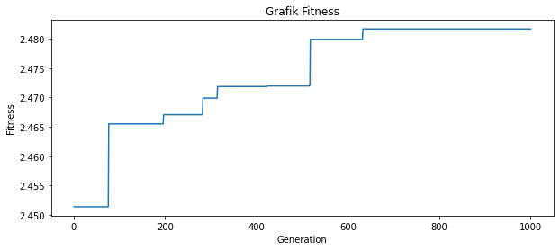

```python
if __name__ == "__main__":
        population_number = int(input("How many population do you want to have? \n [Input Even Number over 10] : "))
        while (population_number % 2 != 0) or (population_number < 10):
            population_number = int(input("How many population do you want to have? \n [Input Even Number over 10] : "))

        generation = int(input("How many generation do you want to have?: "))
        while generation <= 0:
            generation = int(input("How many generation do you want to have?: "))

        fitness_genertaion = []
        generation_numbering = []
        changing_best_kromosome = []
        changing_best_generation = []

        populasi = []
        populasi = initialize_population(population_number)
        best_kromosom = kromosome()

        for i in tqdm(range(generation)):
            calculateKromosomeFitness(populasi)
            populasi = PopulationFitnessSort(populasi)

            #This is for plotting
            generation_numbering.append(i + 1)
            fitness_genertaion.append(populasi[0].fitness)
            # Copyrighted by Kaenova Mahendra Auditama, Adhe Akram Azhari, Elita Aurora Az Zahra
            if best_kromosom.fitness < populasi[0].fitness:
                changing_best_kromosome.append(populasi[0])
                changing_best_generation.append(i)
                best_kromosom = populasi[0]

            elitism = getElitism(populasi)
            parent = tournamentSelection(populasi)
            pasangan = MatingPool(parent)
            populasi_anak = crossover(pasangan)
            populasi_anak = mutation(populasi_anak)
            populasi = elitism + populasi_anak


        #make a plot
        for i in range(len(changing_best_generation)):
            printBestKromosom(changing_best_kromosome[i], changing_best_generation[i])
        plt.figure(figsize=(10,4))
        plt.title("Grafik Fitness")
        plt.xlabel("Generation")
        plt.ylabel("Fitness")
        plt.plot(generation_numbering, fitness_genertaion)
        plt.savefig("./Presentasi/plot.png",dpi=1200, format='png', transparent=False)
```

## Endnote by Author

Pertama-tama kami mengucapkan terima kasih kepada Tuhan Yang Maha Esa serta, dosen kami, Ibu Fhira Nhita dan tidak lupa juga Asisten Doesn yang telah membantu kami mendapatkan ilmu serta menyelesaikan tugas ini.  
Kami tidak bertanggungjawab jika ada yang melakukan plagiarisme atau menyalin kode yang telah kami buat.